# NYC Taxi Fare Prediction

#### Tomoya Tokunaga (October 2018)

This notebook I created for [*New York City Taxi*](https://www.kaggle.com/c/new-york-city-taxi-fare-prediction) Fare Prediction from Kaggle Competition.  
The original datasets were downloadable from the link above.

## Import Dataset

```python
import numpy as np
import pandas as pd
import matplotlib.pyplot as plt
from mpl_toolkits.basemap import Basemap
import seaborn as sns
from mpl_toolkits.basemap import Basemap
from sklearn.linear_model import LinearRegression
from sklearn.metrics import mean_squared_error

% matplotlib inline
```

The training dataset given for the competition has magnitude of data, and reading the whole bunch of data require lots of memory. Hence, we import limited amount of data from the training dataset.

```python
train = pd.read_csv("train.csv", nrows=150000)
data_size = train.shape
train.head()
```

|  | key | fare_amount | pickup_datetime | pickup_longitude | pickup_latitude | dropoff_longitude | dropoff_latitude | passenger_count |
| --- | --- | --- | --- | --- | --- | --- | --- | --- |
| 0 | 2009-06-15 17:26:21.0000001 | 4.5 | 2009-06-15 17:26:21 UTC | -73.844311 | 40.721319 | -73.841610 | 40.712278 | 1 |
| 1 | 2010-01-05 16:52:16.0000002 | 16.9 | 2010-01-05 16:52:16 UTC | -74.016048 | 40.711303 | -73.979268 | 40.782004 | 1 |
| 2 | 2011-08-18 00:35:00.00000049 | 5.7 | 2011-08-18 00:35:00 UTC | -73.982738 | 40.761270 | -73.991242 | 40.750562 | 2 |
| 3 | 2012-04-21 04:30:42.0000001 | 7.7 | 2012-04-21 04:30:42 UTC | -73.987130 | 40.733143 | -73.991567 | 40.758092 | 1 |
| 4 | 2010-03-09 07:51:00.000000135 | 5.3 | 2010-03-09 07:51:00 UTC | -73.968095 | 40.768008 | -73.956655 | 40.783762 | 1 |

```python
train.info()
train.describe()
```

```
<class 'pandas.core.frame.DataFrame'>
RangeIndex: 150000 entries, 0 to 149999
Data columns (total 8 columns):
key                  150000 non-null object
fare_amount          150000 non-null float64
pickup_datetime      150000 non-null object
pickup_longitude     150000 non-null float64
pickup_latitude      150000 non-null float64
dropoff_longitude    149999 non-null float64
dropoff_latitude     149999 non-null float64
passenger_count      150000 non-null int64
dtypes: float64(5), int64(1), object(2)
memory usage: 9.2+ MB
```

|  | fare_amount | pickup_longitude | pickup_latitude | dropoff_longitude | dropoff_latitude | passenger_count |
| --- | --- | --- | --- | --- | --- | --- |
| count | 150000.000000 | 150000.000000 | 150000.000000 | 149999.000000 | 149999.000000 | 150000.000000 |
| mean | 11.361849 | -72.500714 | 39.921610 | -72.507088 | 39.928809 | 1.680407 |
| std | 9.870671 | 10.586363 | 6.131464 | 10.406313 | 6.110042 | 1.305797 |
| min | -44.900000 | -736.550000 | -74.007670 | -84.654241 | -74.015160 | 0.000000 |
| 25% | 6.000000 | -73.992028 | 40.734955 | -73.991258 | 40.734126 | 1.000000 |
| 50% | 8.500000 | -73.981732 | 40.752721 | -73.980042 | 40.753243 | 1.000000 |
| 75% | 12.500000 | -73.966989 | 40.767145 | -73.963473 | 40.768088 | 2.000000 |
| max | 500.000000 | 40.787575 | 401.083332 | 40.851027 | 404.616667 | 6.000000 |

What I noticed from data type information and statistics of each column:

- `dropoff_longitude` and `dropoff_latitude` column has some missing values.
- Columns related to longitudes and latitudes have values which are out of range (latitudes are supposed to be in between -90° and 90°, and longitudes are between -180° and 180°).
- `fare_amount` column has negative amounts although it's supposed have positive amounts.

# Data Cleaning

```python
# removing missing values in the train dataset
train = train.dropna(axis=0)
```

```python
# removing invalid values
train = train[train['pickup_longitude'].between(-74.263, -72.987)]
train = train[train['dropoff_longitude'].between(-74.263, -72.987)]
train = train[train['pickup_latitude'].between(40.569, 41.710)]
train = train[train['dropoff_latitude'].between(40.569, 41.710)]
train = train[train['fare_amount'] >= 0]
train = train.reset_index(drop=True)

print(train.isnull().sum())
train.describe()
```

```
key                  0
fare_amount          0
pickup_datetime      0
pickup_longitude     0
pickup_latitude      0
dropoff_longitude    0
dropoff_latitude     0
passenger_count      0
dtype: int64
```

|  | fare_amount | pickup_longitude | pickup_latitude | dropoff_longitude | dropoff_latitude | passenger_count |
| --- | --- | --- | --- | --- | --- | --- |
| count | 146798.000000 | 146798.000000 | 146798.000000 | 146798.000000 | 146798.000000 | 146798.000000 |
| mean | 11.336091 | -73.974987 | 40.751185 | -73.973907 | 40.751555 | 1.681249 |
| std | 9.747526 | 0.038788 | 0.029885 | 0.038096 | 0.032918 | 1.306294 |
| min | 0.000000 | -74.248263 | 40.572183 | -74.241953 | 40.571222 | 0.000000 |
| 25% | 6.000000 | -73.992235 | 40.736652 | -73.991429 | 40.735741 | 1.000000 |
| 50% | 8.500000 | -73.982039 | 40.753498 | -73.980465 | 40.753965 | 1.000000 |
| 75% | 12.500000 | -73.968285 | 40.767583 | -73.965150 | 40.768395 | 2.000000 |
| max | 500.000000 | -73.085745 | 41.650000 | -73.085764 | 41.543217 | 6.000000 |

```python
# reading test dataset to specify to narrow the region we're going to use
test = pd.read_csv("test.csv")
print(test.isnull().sum())
test.describe()
```

```
key                  0
pickup_datetime      0
pickup_longitude     0
pickup_latitude      0
dropoff_longitude    0
dropoff_latitude     0
passenger_count      0
dtype: int64
```

|  | pickup_longitude | pickup_latitude | dropoff_longitude | dropoff_latitude | passenger_count |
| --- | --- | --- | --- | --- | --- |
| count | 9914.000000 | 9914.000000 | 9914.000000 | 9914.000000 | 9914.000000 |
| mean | -73.974722 | 40.751041 | -73.973657 | 40.751743 | 1.671273 |
| std | 0.042774 | 0.033541 | 0.039072 | 0.035435 | 1.278747 |
| min | -74.252193 | 40.573143 | -74.263242 | 40.568973 | 1.000000 |
| 25% | -73.992501 | 40.736125 | -73.991247 | 40.735254 | 1.000000 |
| 50% | -73.982326 | 40.753051 | -73.980015 | 40.754065 | 1.000000 |
| 75% | -73.968013 | 40.767113 | -73.964059 | 40.768757 | 2.000000 |
| max | -72.986532 | 41.709555 | -72.990963 | 41.696683 | 6.000000 |

```python
# minimum and maximum longitude
mini_lon, maxi_lon = (min(test['pickup_longitude'].min(), test['dropoff_longitude'].min()),
                      max(test['pickup_longitude'].max(), test['dropoff_longitude'].max()))
# minimum and maximum latitude
mini_lat, maxi_lat = (min(test['pickup_latitude'].min(), test['dropoff_latitude'].min()),
                     max(test['pickup_latitude'].max(), test['dropoff_latitude'].max()))

print(f"longitude:({mini_lon}, {maxi_lon})")
print(f"latitude :({mini_lat}, {maxi_lat})")
```

```
longitude:(-74.263242, -72.986532)
latitude :(40.568973, 41.709555)
```

Now we've gotten legitimate information about what area the dataset covers. Let's find out how the dateset looks like by visualization.

```python
def plot_on_nyc_map(data, coordinate):
    fig = plt.figure(figsize=(18,12))
    # this is a map for pickup locations
    ax1 = fig.add_subplot(1,2,1)
    ax1 = Basemap(projection='merc',
        llcrnrlat = coordinate[0],
        urcrnrlat = coordinate[1],
        llcrnrlon = coordinate[2],
        urcrnrlon = coordinate[3],
        resolution='h'
    )
    ax1.fillcontinents(color='#F2EFE9')
    ax1.drawcoastlines()
    ax1.drawmapboundary(fill_color='#AAD3DF')
    pickup_lon = train["pickup_longitude"].tolist()
    pickup_lat = train['pickup_latitude'].tolist()
    ax1.scatter(pickup_lon, pickup_lat, s=4, zorder=2, latlon=True, color="#FF4500", alpha=0.4)
    plt.title("Pickup Locations")

    # this is a map for dropoff locations
    ax2 = fig.add_subplot(1,2,2)
    ax2 = Basemap(
        projection='merc',
        llcrnrlat = coordinate[0],
        urcrnrlat = coordinate[1],
        llcrnrlon = coordinate[2],
        urcrnrlon = coordinate[3],
        resolution='h'
    )
    ax2.fillcontinents(color='#F2EFE9')
    ax2.drawcoastlines()
    ax2.drawmapboundary(fill_color='#AAD3DF')
    dropoff_lon = train["dropoff_longitude"].tolist()
    dropoff_lat = train['dropoff_latitude'].tolist()
    ax2.scatter(dropoff_lon, dropoff_lat, s=4, zorder=2, latlon=True, color="#FF4500", alpha=0.4)

    plt.title("Dropoff Locations")
    plt.show()
```

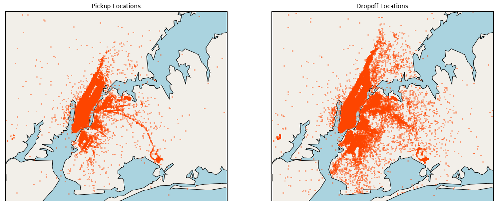

```python
nyc_coordinate = (40.56, 40.95, -74.20, -73.60)

plot_on_nyc_map(train, nyc_coordinate)
```

The scatter plots above tells that some pickup/ dropoff locations are on the ocean. This has to be regarded as noise. So, the next step is removing those invalid plots from the dataset. A Basemap method called `is_land(x, y)` checks if a coordinate (x, y) is on the land. By removing the points whose coordinates is returned `False` by is_land(x, y), we can have much cleaner dataset.

## Remove Points under the Sea

```python
# This function is based on plot_on_nyc_map and added some codes to filter points on the ocean out.
def plot_on_nyc_map_2(data, coordinate):
    fig = plt.figure(figsize=(18,12))
    # this is a map for pickup locations
    ax1 = fig.add_subplot(1,2,1)
    ax1 = Basemap(projection='merc',
        llcrnrlat = coordinate[0],
        urcrnrlat = coordinate[1],
        llcrnrlon = coordinate[2],
        urcrnrlon = coordinate[3],
        resolution='h'
    )
    ax1.fillcontinents(color='#F2EFE9')
    ax1.drawcoastlines()
    ax1.drawmapboundary(fill_color='#AAD3DF')
    # this is a map for pickup locations
    pickup_lon = data["pickup_longitude"]
    pickup_lat = data["pickup_latitude"]
    for i in range(len(pickup_lon)):
        xpt, ypt = ax1(pickup_lon[i], pickup_lat[i])
        if ax1.is_land(xpt, ypt) == False:
            data = data.drop([i])

    data = data.reset_index(drop=True)
    pickup_lon = data["pickup_longitude"].tolist()
    pickup_lat = data['pickup_latitude'].tolist()
    ax1.scatter(pickup_lon, pickup_lat, s=4, zorder=2, latlon=True, color="#FF4500", alpha=0.4)
    plt.title("Pickup Locations")

    # this is a map for dropoff locations
    ax2 = fig.add_subplot(1,2,2)
    ax2 = Basemap(
        projection='merc',
        llcrnrlat = coordinate[0],
        urcrnrlat = coordinate[1],
        llcrnrlon = coordinate[2],
        urcrnrlon = coordinate[3],
        resolution='h'
    )
    ax2.fillcontinents(color='#F2EFE9')
    ax2.drawcoastlines()
    ax2.drawmapboundary(fill_color='#AAD3DF')
    # removing locations on the ocean
    dropoff_lon = data["dropoff_longitude"]
    dropoff_lat = data["dropoff_latitude"]
    for i in range(len(dropoff_lon)):
        xpt, ypt = ax2(dropoff_lon[i], dropoff_lat[i])
        if ax2.is_land(xpt, ypt) == False:
            data = data.drop([i])

    data = data.reset_index(drop=True)
    dropoff_lon = data["dropoff_longitude"].tolist()
    dropoff_lat = data['dropoff_latitude'].tolist()
    ax2.scatter(dropoff_lon, dropoff_lat, s=4, zorder=2, latlon=True, color="#FF4500", alpha=0.4)

    plt.title("Dropoff Locations")
    plt.show()

    return data
```

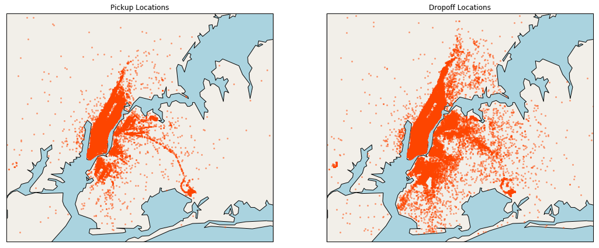

```python
train = plot_on_nyc_map_2(train, nyc_coordinate)
```

```python
train.describe()
```

|  | fare_amount | pickup_longitude | pickup_latitude | dropoff_longitude | dropoff_latitude | passenger_count |
| --- | --- | --- | --- | --- | --- | --- |
| count | 146210.000000 | 146210.000000 | 146210.000000 | 146210.000000 | 146210.000000 | 146210.000000 |
| mean | 11.295664 | -73.975428 | 40.750921 | -73.974276 | 40.751337 | 1.681315 |
| std | 9.547746 | 0.034371 | 0.026760 | 0.034391 | 0.030730 | 1.306452 |
| min | 0.000000 | -74.198678 | 40.576302 | -74.198678 | 40.573200 | 0.000000 |
| 25% | 6.000000 | -73.992236 | 40.736672 | -73.991428 | 40.735764 | 1.000000 |
| 50% | 8.500000 | -73.982055 | 40.753493 | -73.980493 | 40.753965 | 1.000000 |
| 75% | 12.500000 | -73.968362 | 40.767556 | -73.965272 | 40.768390 | 2.000000 |
| max | 500.000000 | -73.608685 | 40.943042 | -73.600296 | 40.945400 | 6.000000 |

## Define "distance" Column

The next step is creating a new column which is related to the trip distance between pickup and dropoff locations because it's very reasonable that fare amount is dependent on how long a customer rides.

We're going to use the Pythagorean theorem to find out approximate trip distance.  
Let's suppose:  
A = Pickup Location  
B = Dropoff Location  
C = Trip Distance  
Then,

$$C = \sqrt{A^2 + B^2}$$

We're going to apply this formula to both latitudu and longitude respectively.

```python
# This function calculates distance of two points using the Pythagorian theorem
def distance_calc(data):
    lat_dis = abs(data["dropoff_latitude"]-data["pickup_latitude"])
    lon_dis = abs(data["dropoff_longitude"]-data["pickup_longitude"])
    return np.sqrt(lat_dis**2 + lon_dis**2)

train['distance'] = distance_calc(train)
test['distance'] = distance_calc(test)
train.head(10)
```

|  | key | fare_amount | pickup_datetime | pickup_longitude | pickup_latitude | dropoff_longitude | dropoff_latitude | passenger_count | distance |
| --- | --- | --- | --- | --- | --- | --- | --- | --- | --- |
| 0 | 2009-06-15 17:26:21.0000001 | 4.5 | 2009-06-15 17:26:21 UTC | -73.844311 | 40.721319 | -73.841610 | 40.712278 | 1 | 0.009436 |
| 1 | 2010-01-05 16:52:16.0000002 | 16.9 | 2010-01-05 16:52:16 UTC | -74.016048 | 40.711303 | -73.979268 | 40.782004 | 1 | 0.079696 |
| 2 | 2011-08-18 00:35:00.00000049 | 5.7 | 2011-08-18 00:35:00 UTC | -73.982738 | 40.761270 | -73.991242 | 40.750562 | 2 | 0.013674 |
| 3 | 2012-04-21 04:30:42.0000001 | 7.7 | 2012-04-21 04:30:42 UTC | -73.987130 | 40.733143 | -73.991567 | 40.758092 | 1 | 0.025340 |
| 4 | 2010-03-09 07:51:00.000000135 | 5.3 | 2010-03-09 07:51:00 UTC | -73.968095 | 40.768008 | -73.956655 | 40.783762 | 1 | 0.019470 |
| 5 | 2011-01-06 09:50:45.0000002 | 12.1 | 2011-01-06 09:50:45 UTC | -74.000964 | 40.731630 | -73.972892 | 40.758233 | 1 | 0.038675 |
| 6 | 2012-11-20 20:35:00.0000001 | 7.5 | 2012-11-20 20:35:00 UTC | -73.980002 | 40.751662 | -73.973802 | 40.764842 | 1 | 0.014565 |
| 7 | 2012-01-04 17:22:00.00000081 | 16.5 | 2012-01-04 17:22:00 UTC | -73.951300 | 40.774138 | -73.990095 | 40.751048 | 1 | 0.045146 |
| 8 | 2012-12-03 13:10:00.000000125 | 9.0 | 2012-12-03 13:10:00 UTC | -74.006462 | 40.726713 | -73.993078 | 40.731628 | 1 | 0.014258 |
| 9 | 2009-09-02 01:11:00.00000083 | 8.9 | 2009-09-02 01:11:00 UTC | -73.980658 | 40.733873 | -73.991540 | 40.758138 | 2 | 0.026593 |

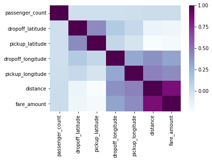

```python
correlation = train.corr()
corr_fare = correlation["fare_amount"]
corr_fare = corr_fare.apply(abs)
sorted_corr = corr_fare.sort_values()

corrmat = train[sorted_corr.index].corr()
sns.heatmap(corrmat, cmap="BuPu")
plt.show()
```

The correlation heatmap above clearly shows that `fare_amount` has the strongest correlation with `distance`. This result gets us determined to use the distance feature to predict fare amount. Now let's refine our training dataset.

```python
cleaned_train = train[['distance', 'fare_amount']]
cleaned_train.describe()
```

|  | distance | fare_amount |
| --- | --- | --- |
| count | 146210.000000 | 146210.000000 |
| mean | 0.033968 | 11.295664 |
| std | 0.038187 | 9.547746 |
| min | 0.000000 | 0.000000 |
| 25% | 0.012834 | 6.000000 |
| 50% | 0.021857 | 8.500000 |
| 75% | 0.038777 | 12.500000 |
| max | 0.398935 | 500.000000 |

## Find Outliers

We have already cleaned our training dataset quite well, but we still have some room for improvement. As we can see from the statistics shown right above this cell, `fare_amount` column seems to have the upper outliers. Removing outliers can make our predictions more accurate.

We're going to identify outliers using the following formula from a Statistics textbook:
Let
$$z = \frac{x - \bar{x}}{\sigma}$$
Then, outlier x is:
$$\{x := x\in\mathbb{R}|z<-3, 3<x\}$$

```python
z = (cleaned_train - cleaned_train.mean())/cleaned_train.std()
z = z[(z > -3) & (z < 3)]
refined_train = z*cleaned_train.std() + cleaned_train.mean()
refined_train = refined_train.dropna(axis=0)
refined_train.describe()
```

|  | distance | fare_amount |
| --- | --- | --- |
| count | 141342.000000 | 141342.000000 |
| mean | 0.029022 | 10.013909 |
| std | 0.024955 | 6.137954 |
| min | 0.000000 | 0.000000 |
| 25% | 0.012636 | 6.000000 |
| 50% | 0.021219 | 8.100000 |
| 75% | 0.036364 | 12.000000 |
| max | 0.148495 | 39.870000 |

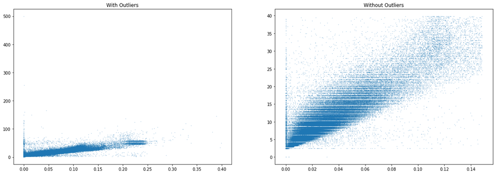

```python
fig = plt.figure(figsize=(21,7))

# this is scatter plots with outliers
ax1 = fig.add_subplot(1,2,1)
ax1.scatter(cleaned_train['distance'], cleaned_train['fare_amount'], s=0.5, alpha=0.3)
ax1.set_title("With Outliers")

# this is scatter plots without outliers
ax2 = fig.add_subplot(1,2,2)
ax2.scatter(refined_train['distance'], refined_train['fare_amount'], s=0.5, alpha=0.3)
ax2.set_title("Without Outliers")

plt.show()
```

Two scatter plots shown above tell us that distance and fare amounts have stronger correlation by removing outliers. Although it seems that removing outliers is always good for more accurate prediction, it could occur we miss some significant data. So we procced creating our machine learning model using both data and decide which we use based on their RMSE(Root Mean Square Error).

Now we've done data cleaning! Let's see how many data we lost.

```python
print("Original data size: " + str(data_size[0]))
print("Cleaned data size : " + str(refined_train.shape[0]))
print("Lost data percentage = " + str(1-(refined_train.shape[0]/data_size[0])))
```

```
Original data size: 150000
Cleaned data size : 141342
Lost data percentage = 0.057719999999999994
```

## Machine Learning Model

For this taxi fare price predicion, we're going to use linear regression model using a scikit-learn package, LinearRegression.

```python
# This is a linear regression model using data with outliers
cleaned_lr = LinearRegression()
cleaned_lr.fit(cleaned_train[['distance']], cleaned_train['fare_amount'])

cleaned_train_predictions = cleaned_lr.predict(cleaned_train[['distance']])
cleaned_test_predictions = cleaned_lr.predict(test[['distance']])
```

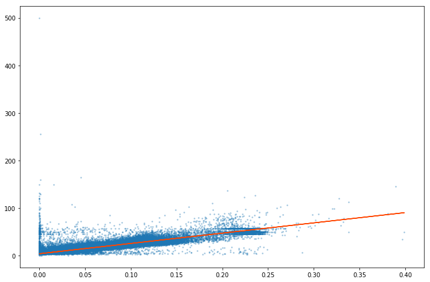

```
RMSE: 4.805712928322796
```

```python
fig = plt.figure(figsize=(12,8))
plt.scatter(cleaned_train['distance'], cleaned_train['fare_amount'], s=3, alpha=0.3)
plt.plot(cleaned_train['distance'], cleaned_train_predictions, linewidth=1.5, c="#FF4500")
plt.show()

# calculate RMSE
cleaned_train_rmse = np.sqrt(mean_squared_error(cleaned_train_predictions, cleaned_train['fare_amount']))
print("RMSE: " + str(cleaned_train_rmse))
```

```python
# This is a linear regression model using data without outliers
refined_lr = LinearRegression()
refined_lr.fit(refined_train[['distance']], refined_train['fare_amount'])

refined_train_predictions = refined_lr.predict(refined_train[['distance']])
refined_test_predictions = refined_lr.predict(test[['distance']])
```

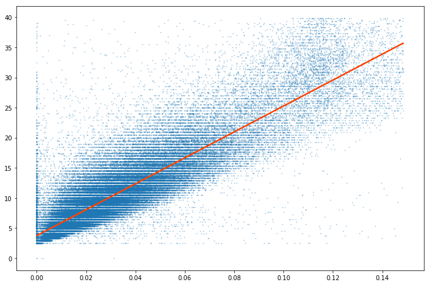

```
RMSE: 2.97610920189374
```

```python
fig = plt.figure(figsize=(12,8))
plt.scatter(refined_train['distance'], refined_train['fare_amount'], s=1, alpha=0.3)
plt.plot(refined_train['distance'], refined_train_predictions, linewidth=2, c="#FF4500")
plt.show()

# calculate RMSE
refined_train_rmse = np.sqrt(mean_squared_error(refined_train_predictions, refined_train['fare_amount']))
print("RMSE: " + str(refined_train_rmse))
```

The RMSE of the model with outliers is much lerger than that of the model without outliers. Since RMSE measures how much errors a model has, we can say the latter model is better to predict taxi fare amounts.

# Conclusion

The list of predicted taxi fare amounts for test dataset is finally here!

```python
fare_predictions = pd.DataFrame(refined_test_predictions)
fare_predictions
```

|  | 0 |
| --- | --- |
| 0 | 8.407383 |
| 1 | 8.757134 |
| 2 | 5.033594 |
| 3 | 7.782575 |
| 4 | 14.662454 |
| 5 | 10.508311 |
| 6 | 6.106467 |
| 7 | 54.626563 |
| 8 | 11.725257 |
| 9 | 6.408927 |
| 10 | 8.466040 |
| 11 | 15.051727 |
| 12 | 5.400661 |
| 13 | 8.044704 |
| 14 | 8.779181 |
| 15 | 14.663570 |
| 16 | 4.525652 |
| 17 | 9.734316 |
| 18 | 5.294325 |
| 19 | 4.858651 |
| 20 | 7.649854 |
| 21 | 8.625586 |
| 22 | 6.348155 |
| 23 | 7.816974 |
| 24 | 15.503228 |
| 25 | 6.464861 |
| 26 | 36.834620 |
| 27 | 23.515342 |
| 28 | 6.046553 |
| 29 | 14.058413 |
| ... | ... |
| 9884 | 33.997503 |
| 9885 | 15.119543 |
| 9886 | 18.993236 |
| 9887 | 8.042412 |
| 9888 | 3.770774 |
| 9889 | 8.429553 |
| 9890 | 9.930718 |
| 9891 | 17.147199 |
| 9892 | 9.950229 |
| 9893 | 14.368932 |
| 9894 | 9.999191 |
| 9895 | 21.750371 |
| 9896 | 9.734396 |
| 9897 | 13.874696 |
| 9898 | 5.025609 |
| 9899 | 17.538201 |
| 9900 | 7.865320 |
| 9901 | 6.740819 |
| 9902 | 13.279962 |
| 9903 | 8.253227 |
| 9904 | 42.226329 |
| 9905 | 23.578426 |
| 9906 | 4.599717 |
| 9907 | 29.092377 |
| 9908 | 7.041076 |
| 9909 | 8.240121 |
| 9910 | 10.427515 |
| 9911 | 50.447952 |
| 9912 | 21.178029 |
| 9913 | 6.631416 |

9914 rows × 1 columns